# House Pricing

Hirley Dayan Louren?o da Silva e Marcia Maria Parmigiani Martins

## Leitura dos Dados

O dataset utilizado nesse trabalho refere-se a dados de im?veis como total de c?modos, idade, etc, o qual foi dividido entre treino, valida??o e teste, com o objetivo de cria??o de um modelo utilizando algoritmo de **Regress?o Linear** para predi??o do pre?o de im?veis.

O dataset de treino possui **12384** observa??es e **10** features.  
O dataset de valida??o possui **4128** observa??es e **10** features.  
O dataset de teste possui **4128** observa??es e **10** features.

## Tratamento dos dados

O dataset possui uma feature categ?rica **ocean_proximity** com 5 n?veis. Considerando que a Regress?o Linear assume que todas as vari?veis independentes s?o num?ricas, iremos utilizar a t?cnica de **hot encoding** para transformar a feature em num?rica, atribuindo valor 1 se o caso se enquadre na determinada categoria. A inclus?o da feature categ?rica possibilitou um resultado melhor para todos os modelos testados.

Al?m disso, foram removidas observa??es de features sem anota??es (NA) nos dados de treino, valida??o e teste.

## Normaliza??o dos dados

A t?cnica de normaliza??o aplicada ao dataset ? a **Min-Max** onde os dados s?o dimensionados em um intervalo fixo, normalmente de 0 ? 1. A feature target **median_house_value** n?o foi inclu?da na normaliza??o.

| longitude | latitude | housing_median_age | total_rooms | total_bedrooms | population | households | median_income | lt1_h_ocean | inland | near_bay | near_ocean | median_house_value |
| --- | --- | --- | --- | --- | --- | --- | --- | --- | --- | --- | --- | --- |
| 0.61 | 0.16 | 1.00 | 0.05 | 0.07 | 0.05 | 0.07 | 0.13 | 1 | 0 | 0 | 0 | 122800 |
| 0.60 | 0.15 | 0.88 | 0.03 | 0.05 | 0.02 | 0.05 | 0.18 | 1 | 0 | 0 | 0 | 140300 |
| 0.20 | 0.58 | 0.63 | 0.00 | 0.00 | 0.00 | 0.00 | 0.25 | 0 | 0 | 1 | 0 | 212500 |
| 0.53 | 0.30 | 0.67 | 0.00 | 0.00 | 0.01 | 0.01 | 0.10 | 0 | 1 | 0 | 0 | 47500 |
| 0.57 | 0.17 | 0.63 | 0.14 | 0.12 | 0.06 | 0.12 | 0.43 | 1 | 0 | 0 | 0 | 389700 |

## Regress?o Linear

O algoritmo de **Regress?o Linear** foi utilizado para predizer os pre?os dos im?veis onde a vari?vel que se deseja encontrar ? a **median_house_value** que representa o valor do im?vel baseado em suas features.

As medidas de avalia??o utilizadas foram a **MAE (Mean Absolute Error)** que calcula a m?dia da diferen?a absoluta entre os valores preditos e os observados e o Coeficiente de Determina??o (R2) que indica qu?o bem o modelo consegue se ajustar sobre um conjunto de predi??es e seus valores verdadeiros, podendo variar entre 0 e 1, sendo que 0 indica que o modelo n?o consegue explicar a variabilidade dos dados e 1 indica que as predi??es se ajustam perfeitamente aos dados (modelo explica toda a variabilidade das predi??es) o que indicar? **overfitting**.

## Resultado dos modelos

Avalia??o para o modelo **baseline**: MAE **50470.57** e R? **63.43**%.

Avalia??o para o modelo **complexo baseado na combina??o de features existentes**: MAE **50999.99** e R? **63.43**%.

Avalia??o para os modelos **complexos baseado em regress?o polinomial**:  
F?rmula grau 1: MAE = **50470.57** e R? = **63.43**%  
F?rmula grau 2: MAE = **50527.82** e R? = **63.91**%  
F?rmula grau 3: MAE = **48052.91** e R? = **66.26**%  
F?rmula grau 4: MAE = **47853.44** e R? = **66.81**%  
F?rmula grau 5: MAE = **47671.35** e R? = **67**%  
F?rmula grau 6: MAE = **47558.52** e R? = **67.21**%  
F?rmula grau 7: MAE = **47958.79** e R? = **61.92**%  
F?rmula grau 8: MAE = **49245.76** e R? = **-19.87**%

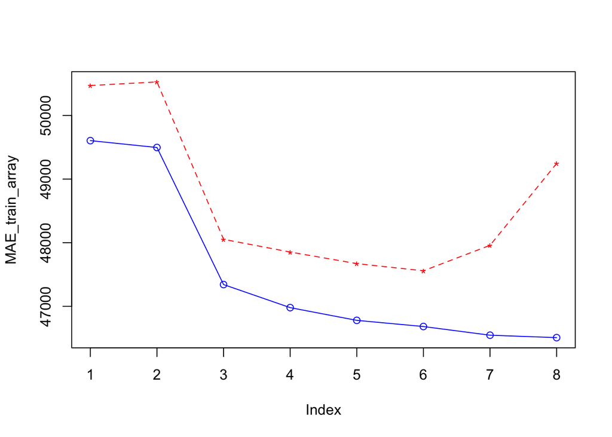

A partir da fun??o de grau 7 percebe-se que os modelos tem um bom desempenho nos dados de treinamento, por?m n?o generaliza, tornando-se muito especializado, o que caracteriza **overfitting**.

## Resultado do melhor modelo no conjunto de teste

Avalia??o para o modelo **polinomial de grau 6**: MAE **46984.26** e R? **68.44**%.